# Лабораторная работа №6

Решение моделей в непрерывном и дискретном времени

Дурдалыев Максат

Российский университет дружбы народов имени Патриса Лумумбы, Москва, Россия

2025-11-22

## Докладчик

- Дурдалыев Максат
- Cтудент НКНбд-01-22
- Российский университет дружбы народов имени Патриса Лумумбы
- 1132205337@pfur.ru
- https://github.com/mdurdalyyev

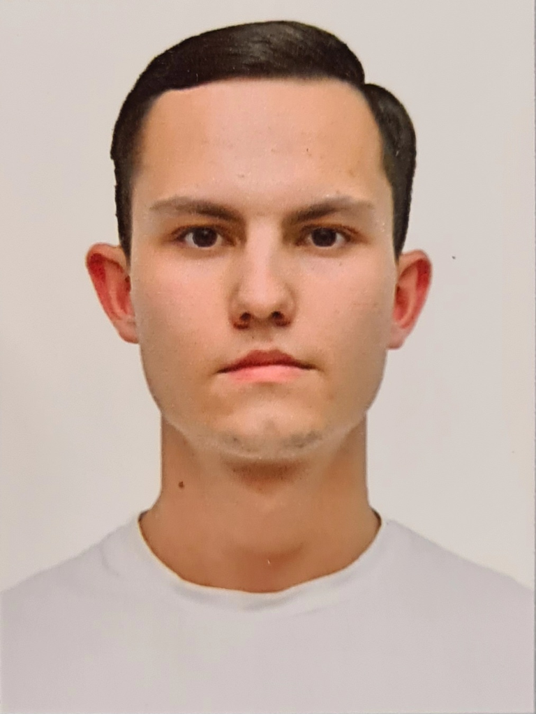

## Цели и задачи

**Цель работы**

Основной целью работы является освоение специализированных пакетов для решения задач в непрерывном и дискретном времени.

**Задание**

1. Используя Jupyter Lab, повторите примеры.
2. Выполните задания для самостоятельной работы.

## Решение обыкновенных дифференциальных уравнений

Вспомним, что обыкновенное дифференциальное уравнение (ОДУ) описывает изменение некоторой переменной u.

Для решения обыкновенных дифференциальных уравнений (ОДУ) в Julia можно использовать пакет diffrentialEquations.jl.

## Модель экспоненциального роста

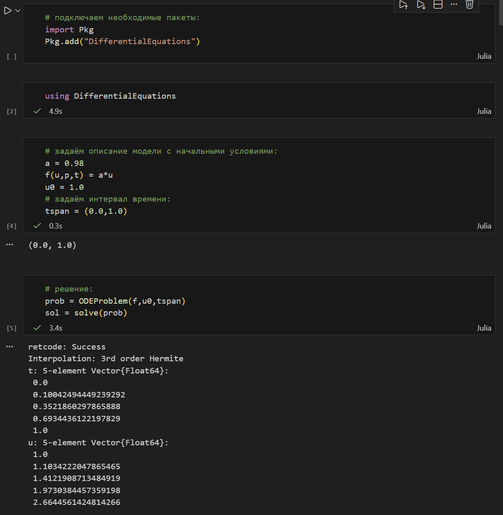

## Модель экспоненциального роста

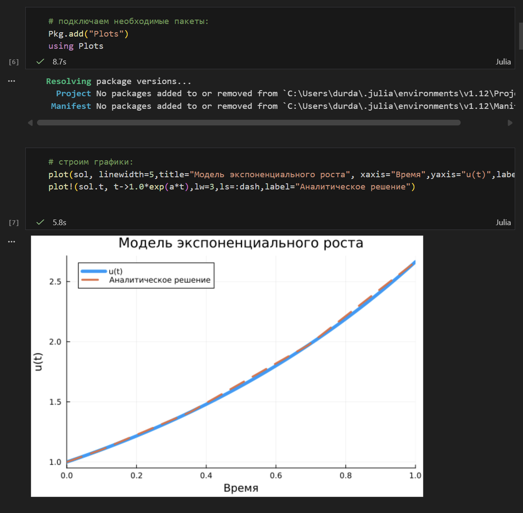

График модели экспоненциального роста

## Модель экспоненциального роста

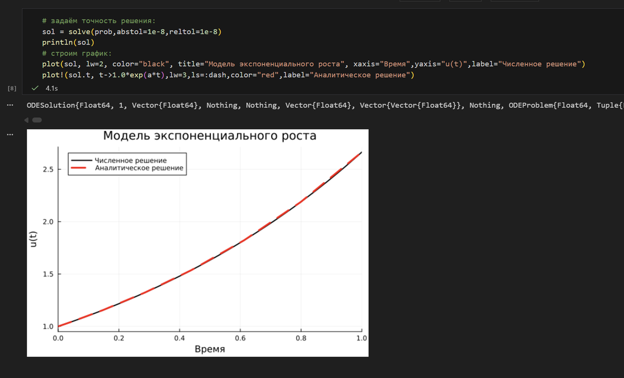

График модели экспоненциального роста (задана точность решения)

## Система Лоренца

Динамической системой Лоренца является нелинейная автономная система обыкновенных дифференциальных уравнений третьего порядка.

Система получена из системы уравнений Навье–Стокса и описывает движение воздушных потоков в плоском слое жидкости постоянной толщины при разложении скорости течения и температуры в двойные ряды Фурье с последующем усечением до первых-вторых гармоник.

Решение системы неустойчиво на аттракторе, что не позволяет применять классические численные методы на больших отрезках времени, требуется использовать высокоточные вычисления.

## Система Лоренца

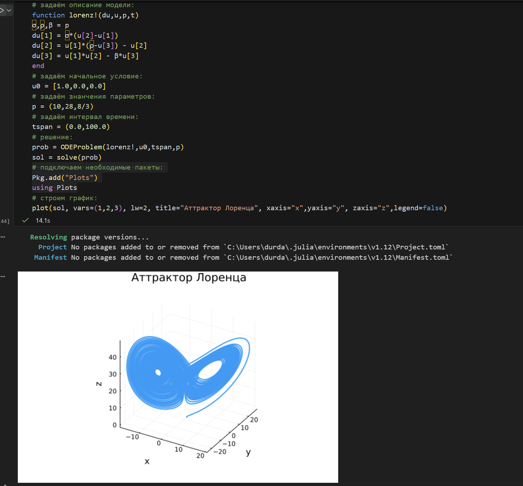

Аттрактор Лоренца

## Система Лоренца

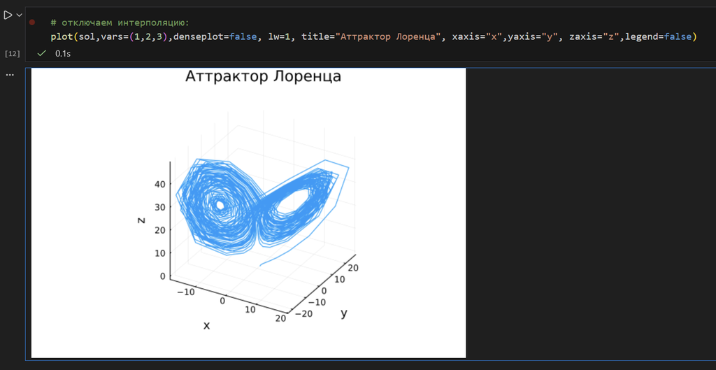

Аттрактор Лоренца (интерполяция отключена)

## Модель Лотки–Вольтерры

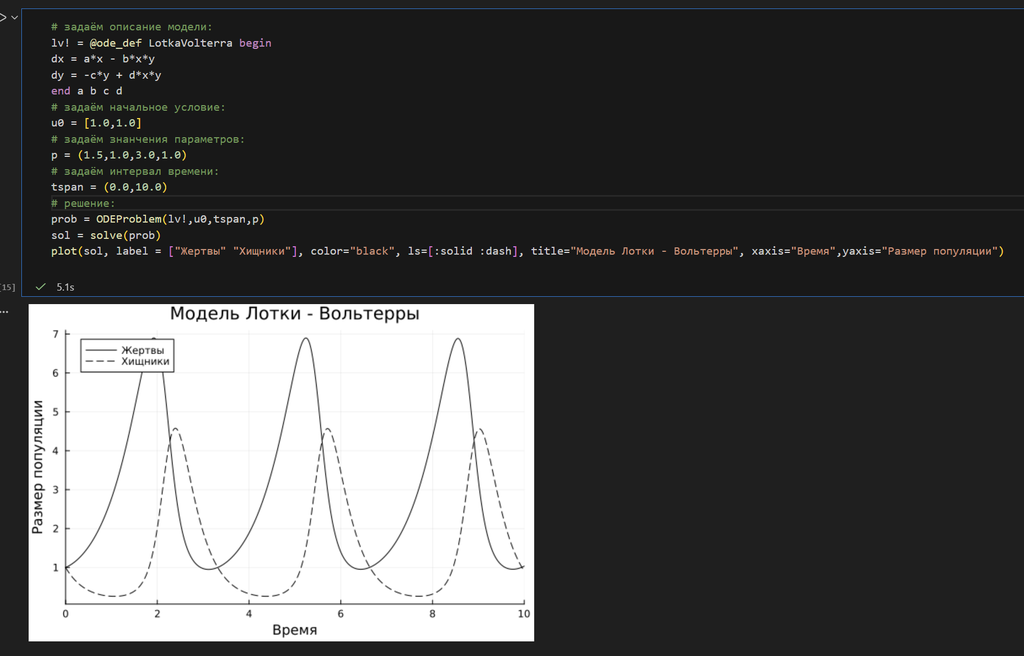

Модель Лотки–Вольтерры: динамика изменения численности популяций

## Модель Лотки–Вольтерры

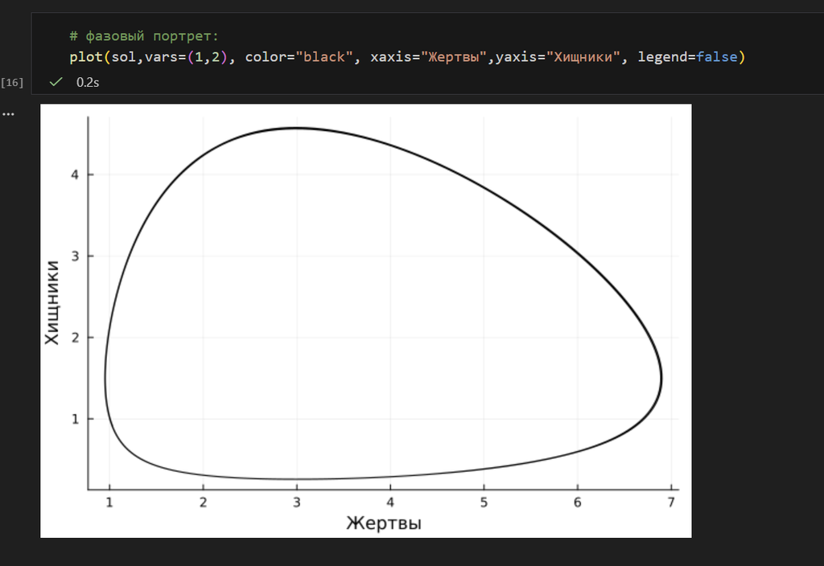

Модель Лотки–Вольтерры: фазовый портрет

## Самостоятельное выполнение

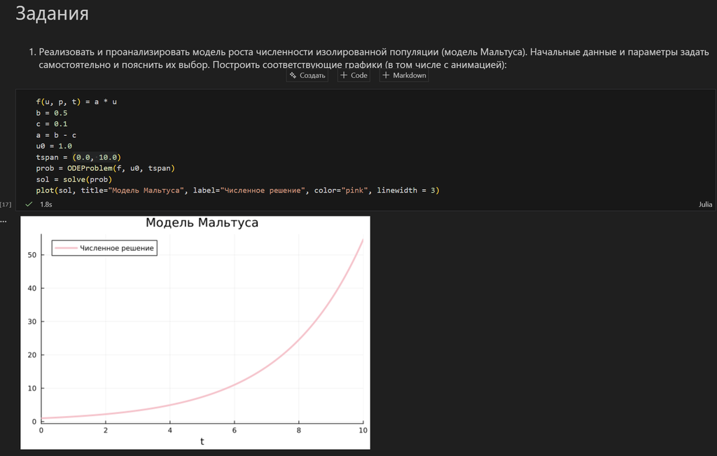

Решение задания №1

## Самостоятельное выполнение

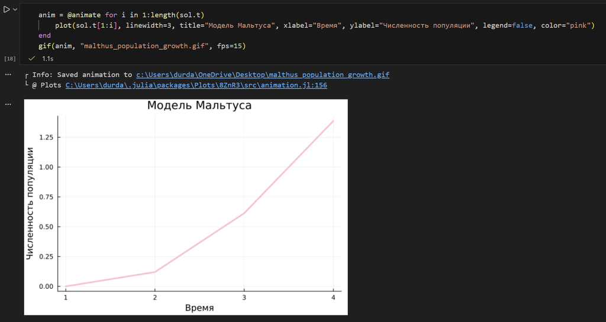

Решение задания №1

## Самостоятельное выполнение

[figure not shown]

## Самостоятельное выполнение

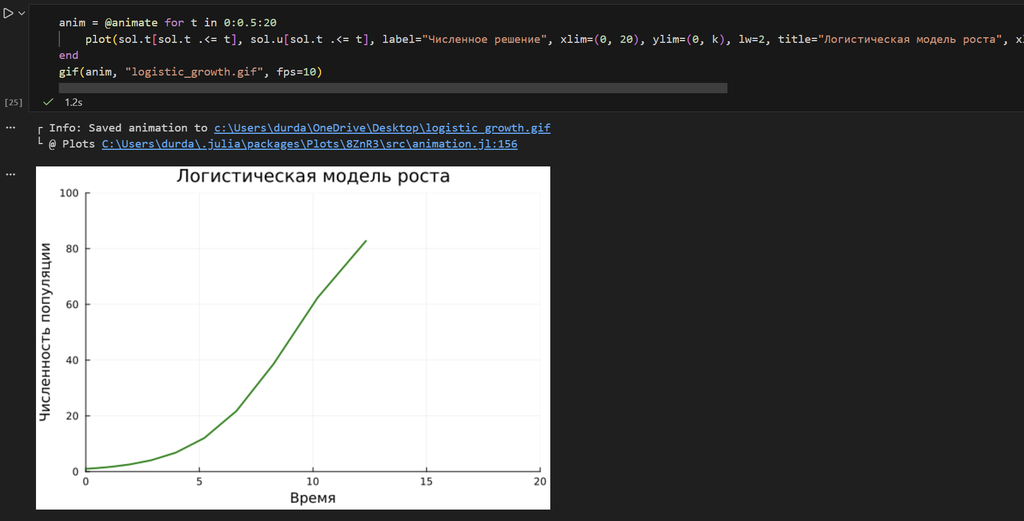

Решение задания №2

## Самостоятельное выполнение

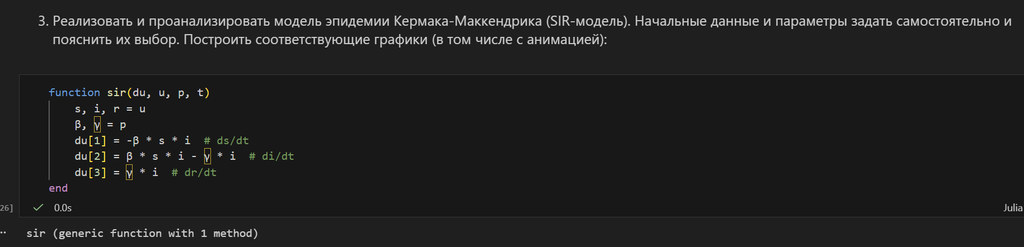

Решение задания №3

## Самостоятельное выполнение

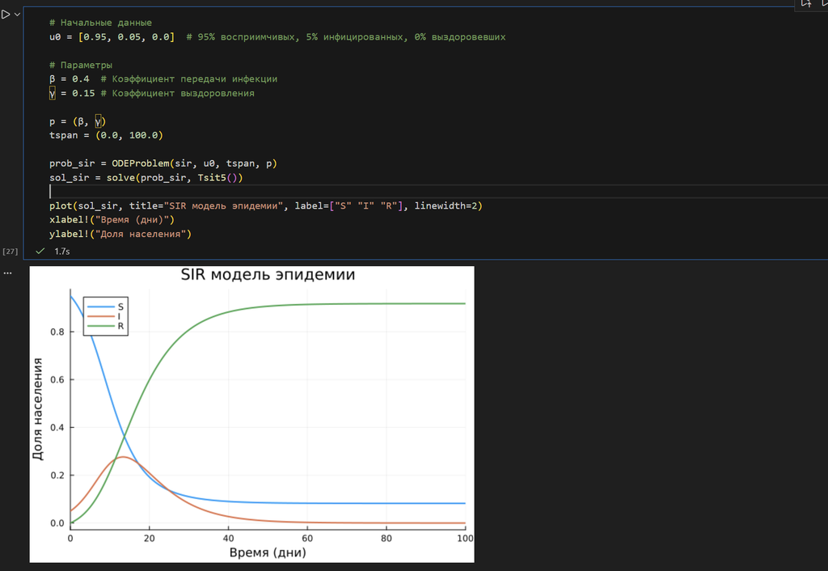

Решение задания №3

## Самостоятельное выполнение

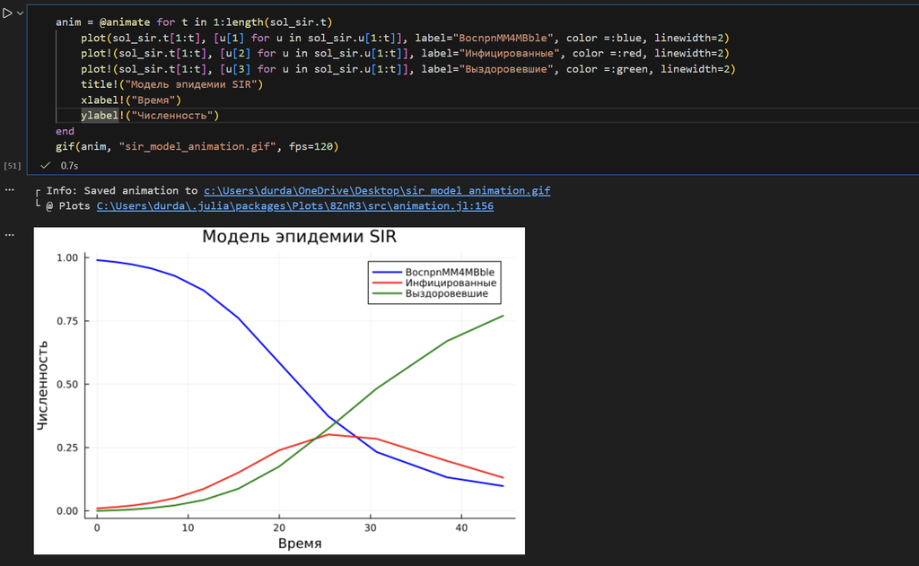

Решение задания №3

## Самостоятельное выполнение

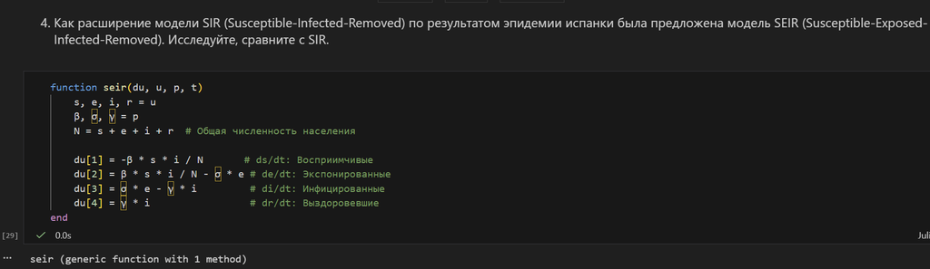

Решение задания №4

## Самостоятельное выполнение

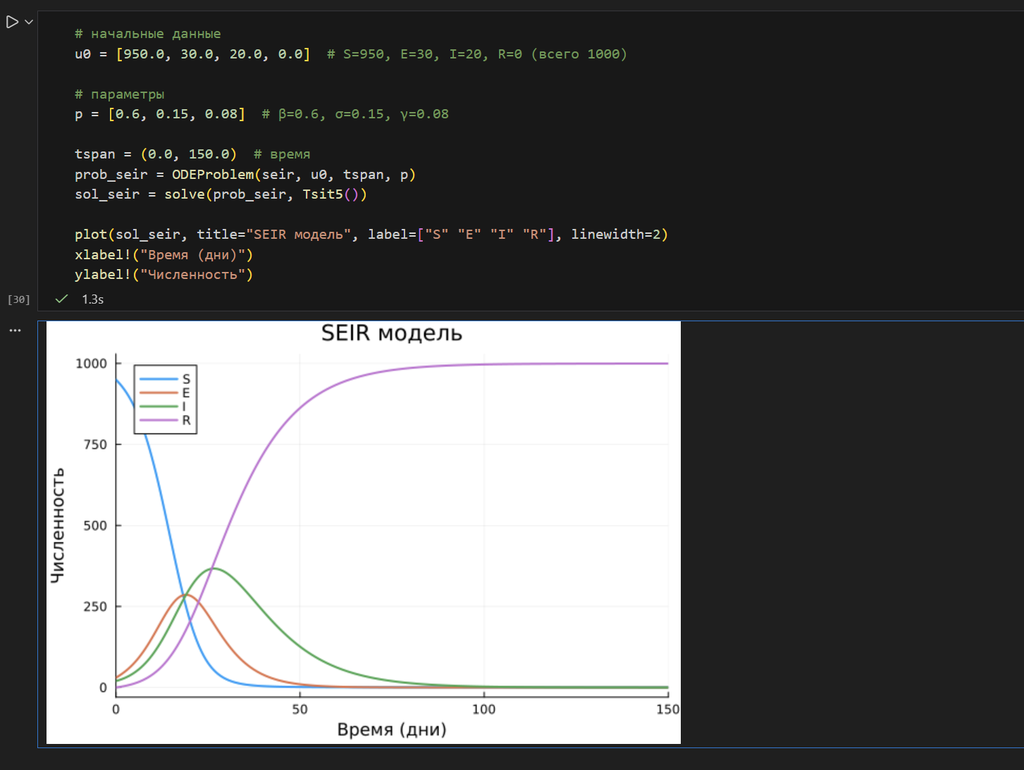

Решение задания №4

## Самостоятельное выполнение

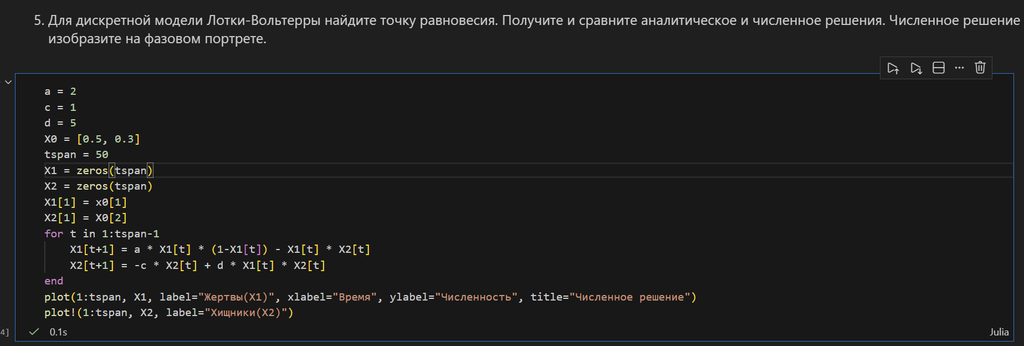

## Самостоятельное выполнение

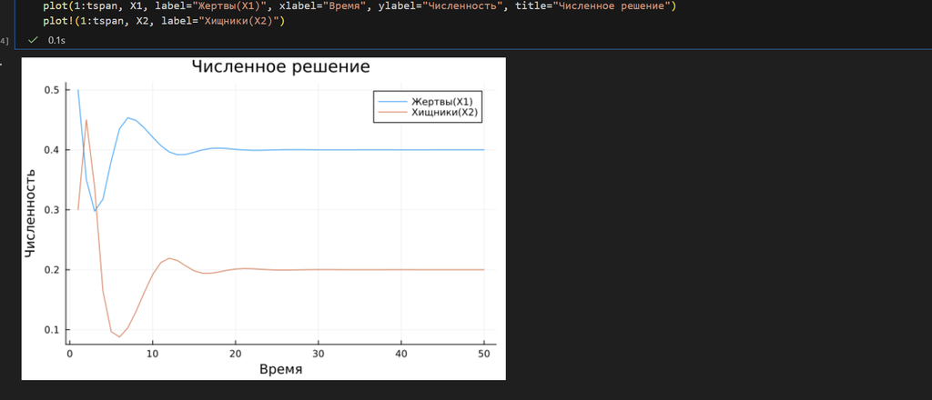

Решение задания №5

## Самостоятельное выполнение

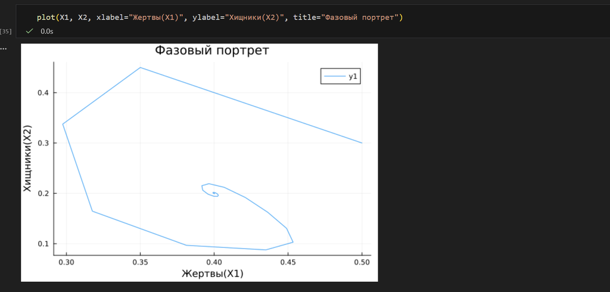

Решение задания №5

## Самостоятельное выполнение

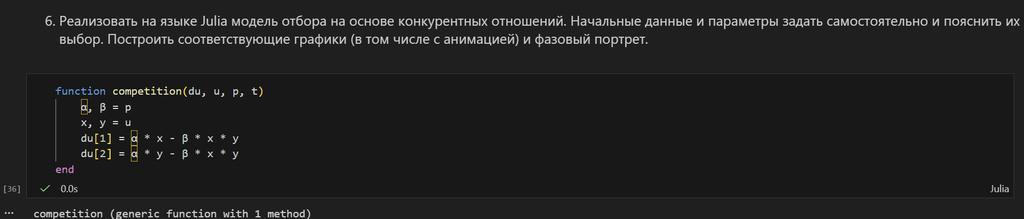

Решение задания №6

## Самостоятельное выполнение

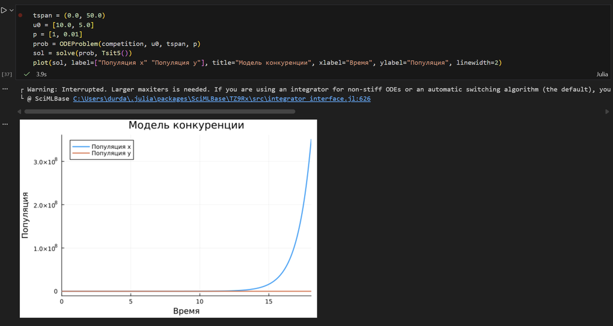

Решение задания №6

## Самостоятельное выполнение

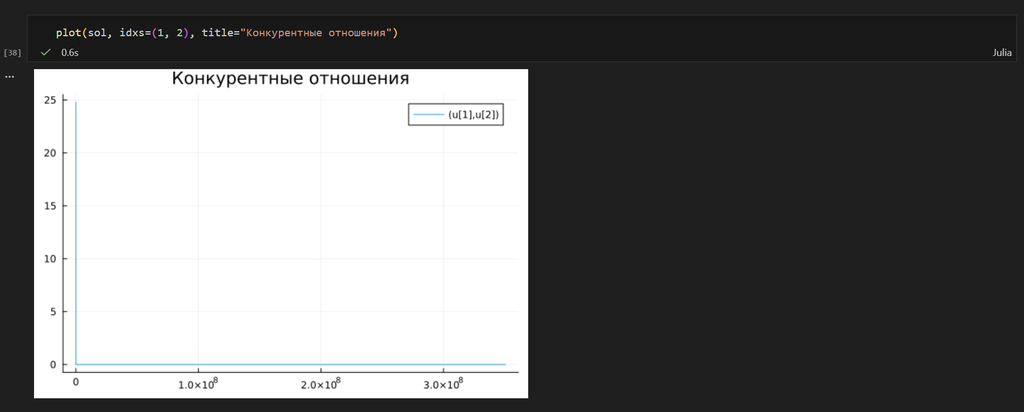

Решение задания №6

## Самостоятельное выполнение

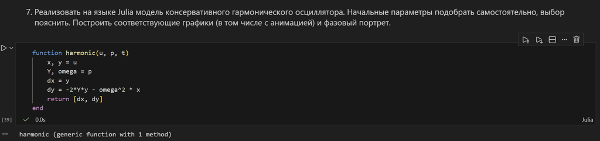

Решение задания №7

## Самостоятельное выполнение

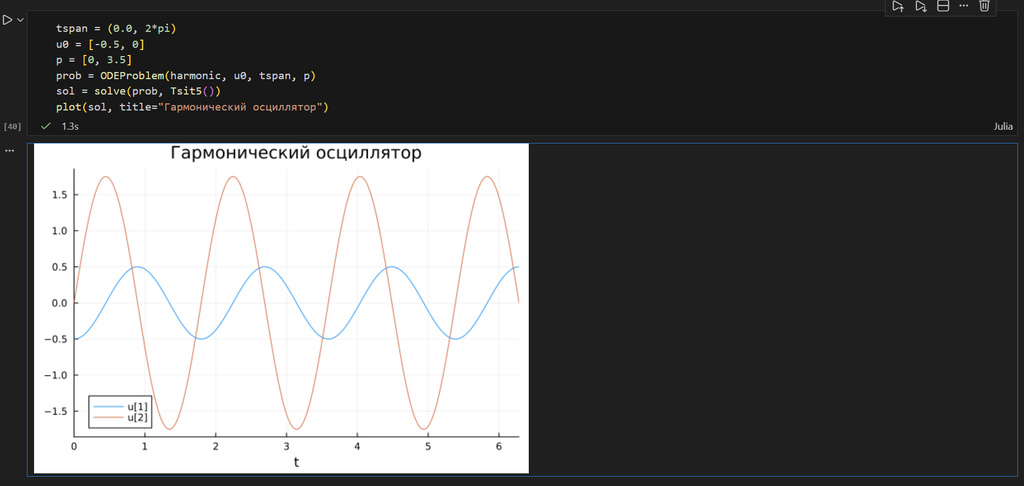

Решение задания №7

## Самостоятельное выполнение

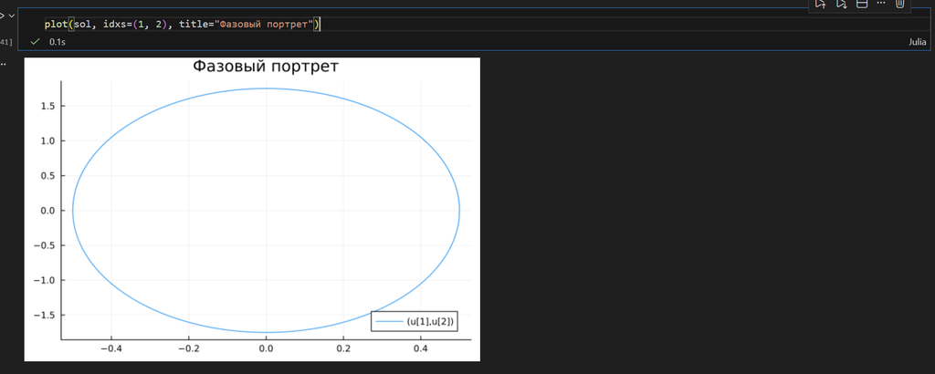

Решение задания №7

## Самостоятельное выполнение

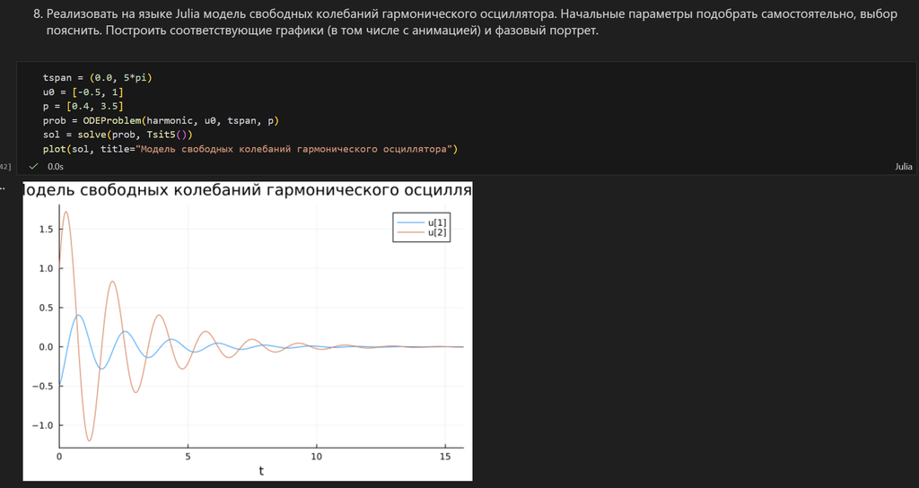

Решение задания №8

## Самостоятельное выполнение

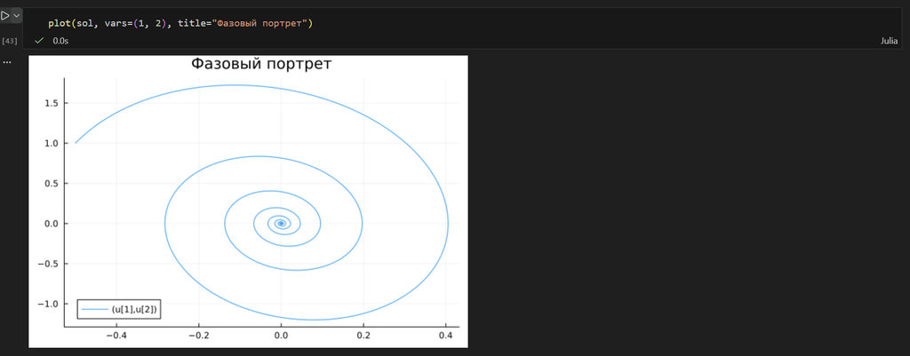

Решение задания №8

## Выводы

В результате выполнения данной лабораторной работы я освоил специализированные пакеты для решения задач в непрерывном и дискретном времени.